# PSY 5939: Longitudinal Data Analysis

# 1 The story so far…

# 1.1 SEM latent growth model

# 1.1.1 Substance use example

Substance use: alcohol, cigarettes, marijuana

Ages 15, 16, 17, and 18

Predictors: gender (female), two parent family, others

101 subjects

No missing data

# 1.1.2 SEM latent growth model

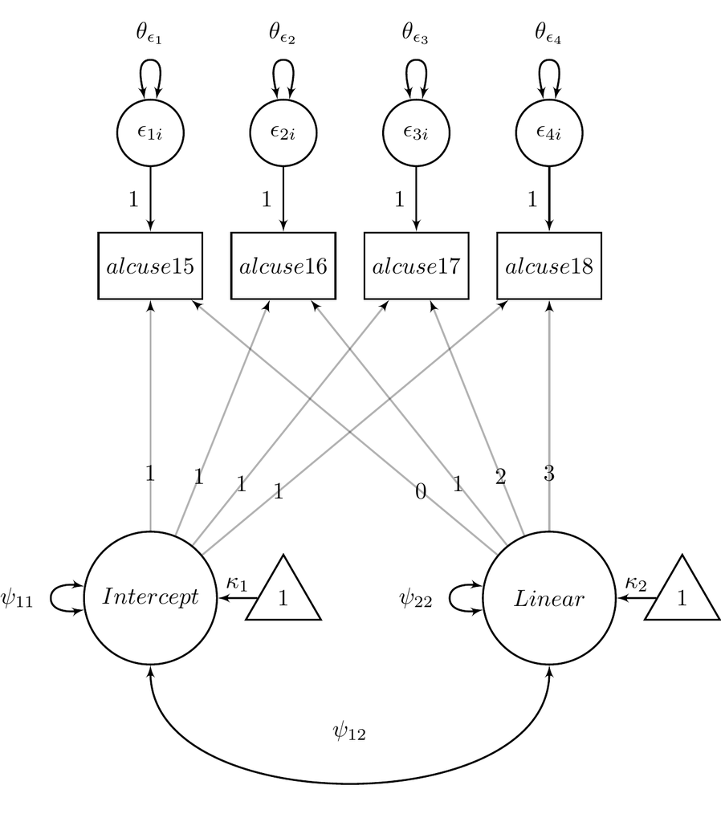

# 1.1.3 Interpret both mean effect and variance

**Average within-person effect**:

Average intercept ($\kappa_1$) is the average alcohol use score at age 15 (time loading = 0)

- Average intercept = 5.890, p<.001
- At age 15, average alcohol use score is 5.890, p<.001

**Between-person variability**

Intercept variance ($\psi_{11}$) tells you how the intercept varies across people  
About 95% of people have intercepts in [mean intercept $\pm 1.96\sqrt{variance}$]

- Intercept variance = 0.552, p<.001
- SD = $\sqrt{0.552}$=0.743
- About 95% of participants had intercepts between 4.43 and 7.35

# 1.1.4 Interpret both mean effect and variance

**Average within-person effect**:

Average linear slope ($\kappa_2$) is the average increase in the outcome for a 1-unit increase in time

- Average slope = 0.108, p<.01
- Each year, alcohol use scores increase an average of 0.108 points, p<.01

**Between-person variability**

Slope variance ($\psi_{22}$) tells you how the slope varies across people  
About 95% of people have slopes in [mean slope $\pm 1.96\sqrt{variance}$]

- Slope variance = 0.037, p<.05
- SD = $\sqrt{0.037}$=0.192
- About 95% of participants had slopes between -0.269 and 0.485

# 1.1.5 Model fit

Relative and absolute measures of fit

- LR test to compare models
- $\chi^2$, CFI, RMSEA, SRMR
- Often (sometimes?) agree

Person-specific schedule: no $\chi^2$, CFI, RMSEA

Potential misfit in structural and/or measurement portion of model

# 1.1.6 Predictors of growth

**Time invariant predictors:**

- Do not change over time – intervention group, gender, etc.
- Predictor predicts latent intercept and slope

**Time varying predictors:**

- Different value at each assessment – stress, substance use, etc.
- Predictor predicts their respective outcome (Y) variable

Good to build up the model **without** predictors first

# 1.2 Alternative: multi-group model

# 1.2.1 Time-invariant predictor

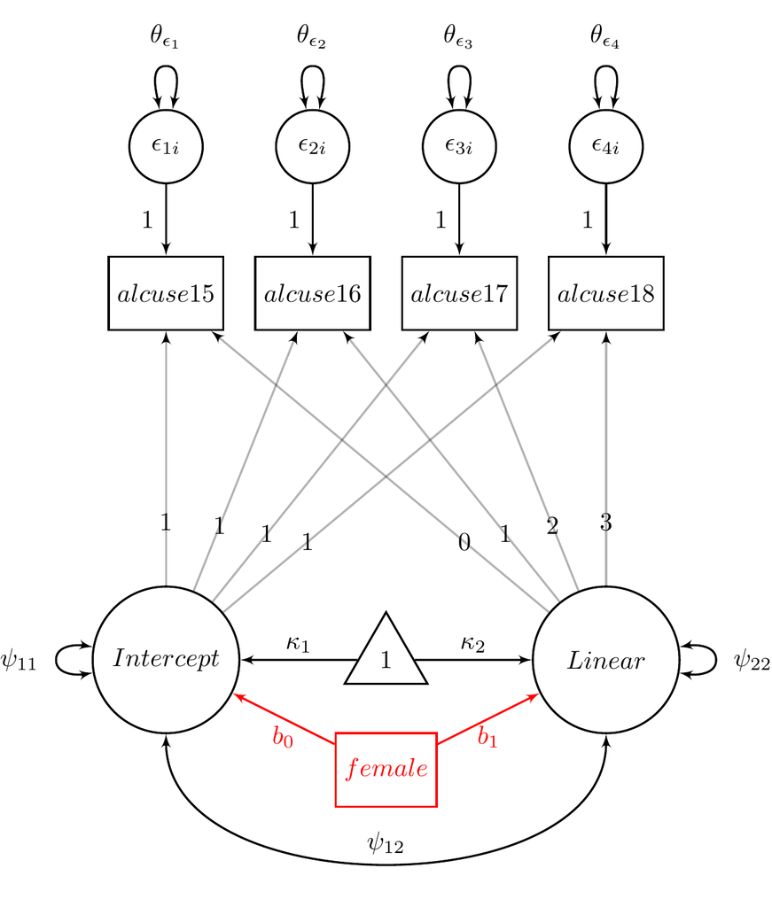

# 1.2.2 Time invariant predictor

When you just add the group variable as a predictor, you’re saying that there’s a **common model** for both groups

For example:

- The intercept variance and slope variance are the same for both groups
- The residual variance situation is the same for both groups
  - e.g., equal residual variances in both
- The residual covariance between the intercept and the slope is the same for both groups

The only way that the groups are different is their **mean intercept** and **mean slope**

# 1.2.3 Multi-group model

Alternative for *categorical* time-invariant predictors

You can only do this in an SEM package

- This is an extension of latent growth models that has no parallel in mixed models

**Essentially**, you run *separate* models for each group within a single analysis

- **Test** whether parts of the model (e.g., intercept variance, slope variance) are the same
- Rather than **assuming** that they are (as in the time invariant predictor model)

# 1.2.4 Mplus code for multi-group models

**In the VARIABLE: section**

`grouping is female (0 = male 1 = female);`

If you just add this line to your model, it will run a multigroup model in which **all parameters** can vary across the groups

- Basically, two completely separate models in one model

# 1.2.5 Group-specific constraints

“Constraints” are the general term for things like making all the residual variances be equal

- You request that certain values are estimated or not, or that certain values equal a certain value, or equal some other value
- You can impose *group-specific* constraints in the model, so something like
  - Something is constrained in one group but not the other
  - Something is constrained in different ways in each group

# 1.2.6 Constraint: equal residual variances within group

To constrain the model such that each group has equal residual variances *but the groups have different values*

In the MODEL section

`MODEL female:`  
`alcuse15 - alcuse18 (1);`

`MODEL male:`  
`alcuse15 - alcuse18 (2);`

This will allow residual variances to be **different** across the groups

Remember that:

- The parameters labeled (1) will have one value and the parameters labeled (2) will have a different value
- (Otherwise, they’ll be the same in both groups)
- This means that *girls* will have equal residual variances across time with *one value* and *boys* will have equal residual variances across time with a *different value*

# 1.2.7 Error message

The model so far: linear growth, equal residual variances (different across groups) gives an **error**

`THE MODEL ESTIMATION TERMINATED NORMALLY WARNING: THE LATENT VARIABLE COVARIANCE MATRIX (PSI) IN GROUP MALE IS NOT POSITIVE DEFINITE. THIS COULD INDICATE A NEGATIVE VARIANCE/RESIDUAL VARIANCE FOR A LATENT VARIABLE, A CORRELATION GREATER OR EQUAL TO ONE BETWEEN TWO LATENT VARIABLES, OR A LINEAR DEPENDENCY AMONG MORE THAN TWO LATENT VARIABLES. CHECK THE TECH4 OUTPUT FOR MORE INFORMATION. PROBLEM INVOLVING VARIABLE LIN.`

Important parts:

1. THE **LATENT VARIABLE COVARIANCE MATRIX (PSI)** IN **GROUP MALE** IS **NOT POSITIVE DEFINITE**.
2. THIS COULD INDICATE A **NEGATIVE VARIANCE/RESIDUAL VARIANCE** FOR A LATENT VARIABLE, A **CORRELATION GREATER OR EQUAL TO ONE** BETWEEN TWO LATENT VARIABLES, OR A **LINEAR DEPENDENCY** AMONG MORE THAN TWO LATENT VARIABLES.
3. PROBLEM INVOLVING **VARIABLE LIN**.

# 1.2.8 Abbreviated results: error

```r
MODEL RESULTS

                                                    Two-Tailed
                    Estimate       S.E.  Est./S.E.    P-Value

Group MALE
...
 Means
    INT                5.838      0.118     49.580      0.000
    LIN                0.040      0.041      0.997      0.319
...
 Variances
    INT                0.334      0.142      2.347      0.019
    LIN               -0.014      0.021     -0.653      0.513

 Residual Variances
    ALCUSE15           0.454      0.066      6.856      0.000
    ALCUSE16           0.454      0.066      6.856      0.000
    ALCUSE17           0.454      0.066      6.856      0.000
    ALCUSE18           0.454      0.066      6.856      0.000

Group FEMALE
...
 Means
    INT                5.935      0.135     43.923      0.000
    LIN                0.167      0.052      3.218      0.001
...
 Variances
    INT                0.737      0.193      3.824      0.000
    LIN                0.074      0.030      2.498      0.012

 Residual Variances
    ALCUSE15           0.356      0.048      7.348      0.000
    ALCUSE16           0.356      0.048      7.348      0.000
    ALCUSE17           0.356      0.048      7.348      0.000
    ALCUSE18           0.356      0.048      7.348      0.000
```

# 1.2.9 Constraint: slope variance fixed to 0 for boys

The **linear slope variance** for *boys* is **negative**

- This is an impossible value
- Often it’s because that the value is very small

**Since the linear slope variance seems to be very small**, we can impose an *additional constraint* that it’s just 0

`MODEL male:`  
`alcuse15 - alcuse18 (2);`  
`lin@0;`

Remember that:

- Naming a variable refers to its *variance*
- The @ followed by a number *fixes* the parameter to that value
- So `lin@0` fixes the *linear variance* to *0*

# 1.2.10 Abbreviated results: slope variance fixed to 0 for boys

```r
MODEL RESULTS

                                                    Two-Tailed
                    Estimate       S.E.  Est./S.E.    P-Value

Group MALE
...
 Means
    INT                5.838      0.121     48.441      0.000
    LIN                0.040      0.043      0.943      0.346
...
 Variances
    INT                0.381      0.102      3.746      0.000
    LIN                0.000      0.000    999.000    999.000
...

Group FEMALE
...
 Means
    INT                5.935      0.135     43.923      0.000
    LIN                0.167      0.052      3.218      0.001
...
 Variances
    INT                0.737      0.193      3.824      0.000
    LIN                0.074      0.030      2.498      0.012
...
```

# 1.2.11 Plot of effects

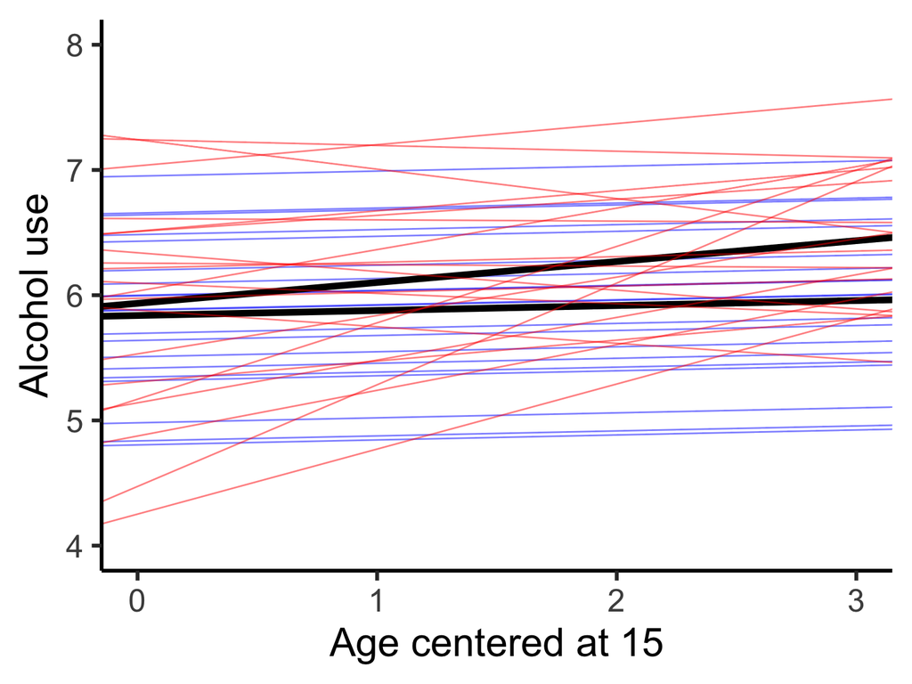

# 1.2.12 Next steps: constrain the model in some way

Note that you estimate twice as many parameters because there are basically now 2 models

- Do you need so many? Could you get by with **some** parameters being the same across groups?

Just like before, we want to know if a **simpler model** is as good as the more complex one

- We can compare them using a LR test

# 1.2.13 Constraint: mean intercept equal across groups

Test whether the mean intercept is the same across groups:

`MODEL female:`  
`alcuse15 - alcuse18 (1);`  
`[int] (3);`

`MODEL male:`  
`alcuse15 - alcuse18 (2);`  
`lin@0;`  
`[int] (3);`

Remember that:

- Naming a variable in [brackets] refers to its *mean*
- Parameters with the same number in (parentheses) at the end have the *same value*
- So `[int] (3);` in both group models constrains the *mean intercept* to be the same for both groups

# 1.2.14 Abbreviated results: mean intercept equal across groups

```r
MODEL RESULTS

                                                    Two-Tailed
                    Estimate       S.E.  Est./S.E.    P-Value

Group MALE
...
 Means
    INT                5.881      0.090     65.180      0.000
    LIN                0.032      0.040      0.805      0.421
...
Group FEMALE
...
 Means
    INT                5.881      0.090     65.180      0.000
    LIN                0.183      0.043      4.289      0.000
...
```

# 1.2.15 LR test

Compare the model where the *mean intercept* is **different across groups** to the model where the *mean intercept* is the **same across groups** using LR test

| Model | Log-likelihood | -2LL | # parameters |
| --- | --- | --- | --- |
| Equal intercept means | -478.458 | 956.916 | 9 |
| Different intercept means | -478.315 | 956.630 | 10 |
|  |  | 0.286 | 1 |

**Conclude** that both groups have the same mean intercept

# 1.2.16 When would you use this?

**Use the “time invariant predictor” approach if…**

- You think that the model is essentially the same across groups, just that there’s a **mean** difference between the groups
- (In SEM, this idea is called “invarian**ce**” – not to be confused with an invaria**nt** predictor, but saying that *all parts of the model* are “invariant” or the same across groups)

**Use the multigroup approach if…**

- You think that the model (**especially variances and covariances**) could be different across groups and that’s interesting
- It’s a little more difficult to implement, but you can learn a lot about the details of the relationships
  - Generally follow up the main model with some “invariance” testing to determine the simplest model you can get away with (as we did with the mean intercept)

# 2 Growth as a predictor

# 2.1 Growth as a predictor

# 2.1.1 Time-varying predictors

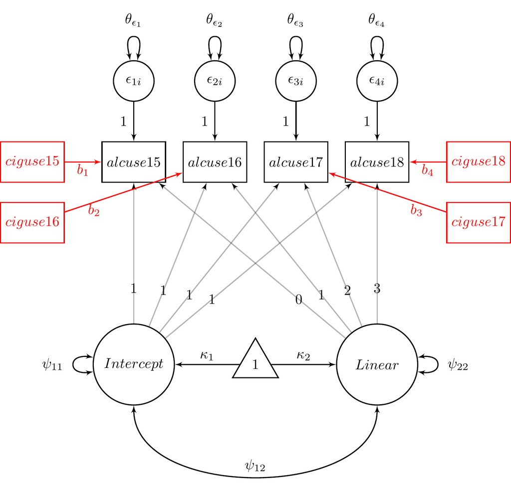

# 2.1.2 Extensions of time-varying “predictor”

So far, our models have had an outcome that is repeatedly measured

- (Alcohol use is the outcome: arrows point TO alcohol use)

What if we are instead / also interested in a **predictor** that is repeatedly measured?

- We already talked about including time varying predictors
- There are two other extensions in this direction
  - Growth as a predictor: multiple measures of predictor in a growth model predict a single outcome
  - Parallel process: two different growth processes are related to (correlated with) one another

# 2.1.3 Growth as a predictor

Growth parameters (latent intercept, latent slope, etc) predict some other variable

- How does change (growth) in alcohol use during adolescence predict marijuana use as an adult?
- How does change (growth) in fasting blood sugar during 20s predict diabetes diagnosis in 30s?
- How does change (growth) in reading ability in grades K - 3 predict high school graduation?

# 2.1.4 Growth as a predictor

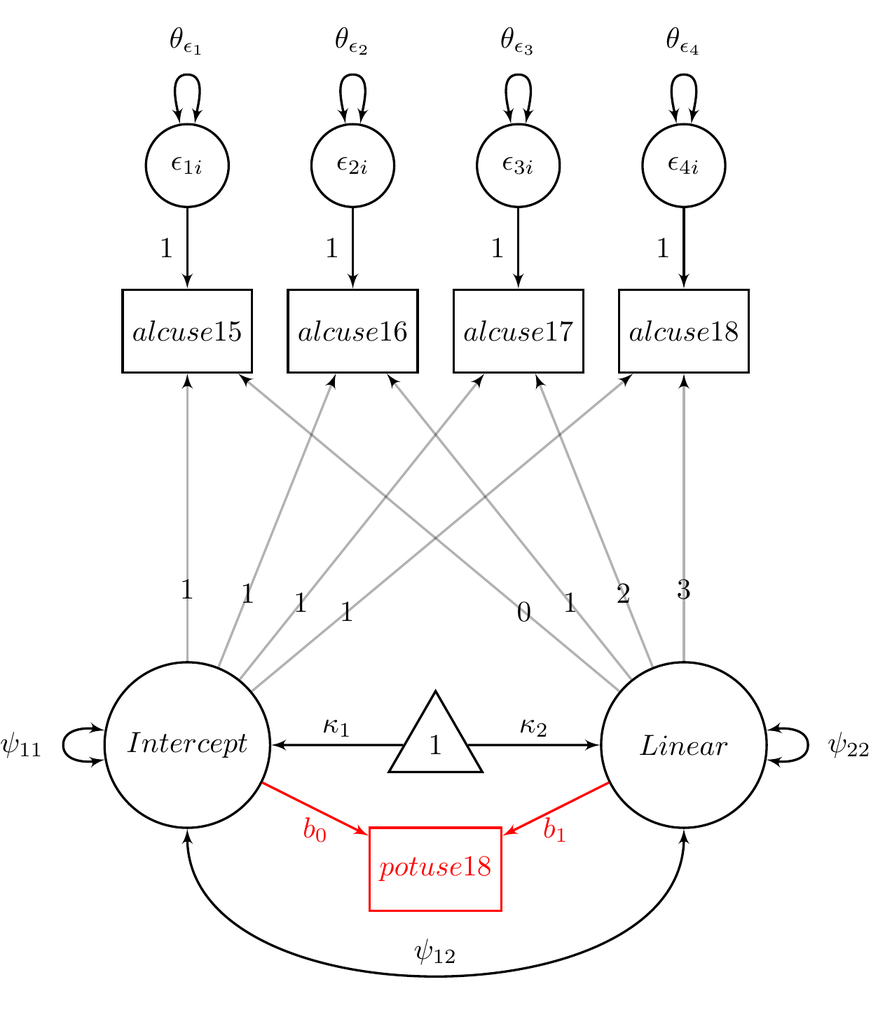

# 2.1.5 Syntax for growth as predictor

Include this line in your MODEL statement:

`outcome on int lin;`

`int lin` are whatever you named your intercept and slope (and quadratic trend, if you have one)

`outcome` is the variable your growth parameters are predicting

For this to make the most sense, the *outcome* should occur **after** the period of *growth*

# 2.2 Interpretation

# 2.2.1 Growth as predictor example

“linear eqresvar - predict mj18”

- Alcohol use at age 15 through 18
- Linear growth model with equal residual variances
- Growth parameters for alcohol use predict marijuana use at age 18
- Age centered at age 15

2 latent variable means (intercept, linear slope)  
2 latent variable variances (intercept, linear slope)  
1 latent variable covariance (Int w Lin)  
1 residual variance (same for all time points)  
2 effects of growth parameters on marijuana use  
1 marijuana use intercept (mean)  
1 marijuana use (residual) variance  
= 2 + 2 + 1 + 1 + 2 + 1 + 1 = 10 estimated parameters

# 2.2.2 Intercept interpretation

Average intercept is the average value of outcome at time = 0

- Average intercept = 5.890 (at age 15)
- At age 15, participants had an average alcohol use score of 5.890, p<.001

Intercept variance is how people vary in their intercepts  
About 95% of people have intercepts in [mean intercept $\pm 1.96\sqrt{variance}$]

- Intercept variance = 0.552, p<.001
- SD = $\sqrt{0.552}$ = 0.743
- At the beginning of the study, about 95% of people had alcohol use scores between 4.43 and 7.35

# 2.2.3 Linear slope interpretation

Average linear slope is the average linear increase in the outcome for a 1-unit increase in time, at time = 0

- Average slope = 0.108
- The linear change in alcohol use is 0.108 points per year, p<.01

Slope variance is how people vary in their slopes  
About 95% of people have slopes in [mean slope $\pm 1.96\sqrt{variance}$]

- Slope variance = 0.037, p<.05
- SD = $\sqrt{0.037}$ = 0.192
- About 95% of people had slopes between -0.269 and 0.485

# 2.2.4 Compare to original growth model

Compare these results to the original linear growth model “linear eqresvar”  
The growth portion of the model is exactly the same

This will *generally* happen, but sometimes it won’t if:

- You have a lot of missing data (in general)
- You have a lot of missing data at a certain time point
- (especially if missingness is related to the outcome)

There may be *slight* variations in the numbers

# 2.2.5 Effects on age 18 marijuana use

**Mean for marijuana use** = 0.792, NS

**Intercept effect on age 18 marijuana use** = 0.727, p<.001

- Age 15 alcohol use significantly predicts age 18 marijuana use
- 1-unit increase in age 15 alcohol use means 0.727 point increase in marijuana use at age 18

**Linear slope effect on age 18 marijuana use** = 1.407, NS

- Linear growth in alcohol use does not predict age 18 marijuana use
- (1-unit increase in linear growth at age 15 means a 1.407 point increase in marijuana use at age 18, NS)

# 2.3 Growth as predictor and outcome

# 2.3.1 Growth as predictor and outcome

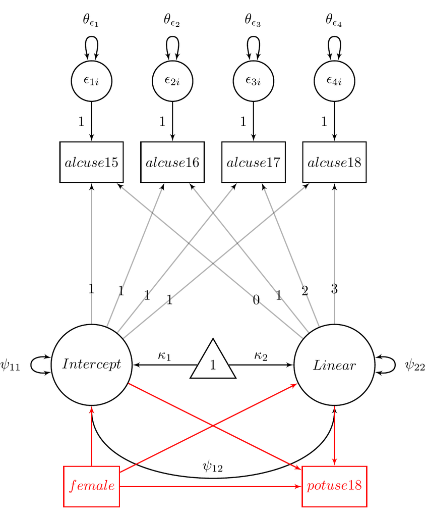

# 2.3.2 Syntax for predictor of growth and growth as predictor

Include these lines in your **MODEL** statement

`outcome on int lin;`

`int lin on predictor;`

`outcome on predictor;`

# 2.3.3 Example

“linear eqresvar - predict mj18 gender predict”

- Alcohol use at age 15 through 18
- Linear growth model with equal residual variances
- Age centered at age 15
- Intercept and linear slope predict marijuana use at age 18
- female is a time invariant predictor of intercept, linear slope
- female coded as (male = 0, female = 1)

# 2.3.4 Gender predicts growth AND growth predicts MJ use

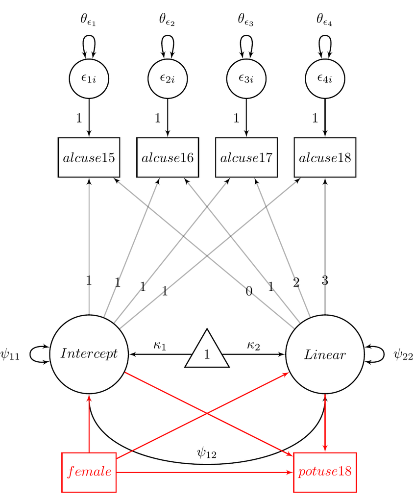

# 2.3.5 Linear model :(

`NO CONVERGENCE. NUMBER OF ITERATIONS EXCEEDED.`

Increase the number of iterations to 100000 (default is 500)

- Still no luck

Mplus does give some results, but no standard errors:

```r
MODEL RESULTS

                    Estimate

 INT      |
    ALCUSE15           1.000
    ALCUSE16           1.000
    ALCUSE17           1.000
    ALCUSE18           1.000

 LIN      |
    ALCUSE15           0.000
    ALCUSE16           1.000
    ALCUSE17           2.000
    ALCUSE18           3.000

 INT      ON
    FEMALE             0.104

 LIN      ON
    FEMALE             0.123

 POTUSE18 ON
    INT                0.568
    LIN               -0.190

 POTUSE18 ON
    FEMALE            -0.431

 Intercepts
    ALCUSE15           0.000
    ALCUSE16           0.000
    ALCUSE17           0.000
    ALCUSE18           0.000
    POTUSE18           2.146
    INT                5.831
    LIN                0.044

 Residual Variances
    ALCUSE15           0.463
    ALCUSE16           0.463
    ALCUSE17           0.463
    ALCUSE18           0.463
    POTUSE18           0.777
    INT                0.368
    LIN               -0.005
```

# 2.3.6 Quadratic model: slightly different problem

Exact same model as before, only with a quadratic growth model for alcohol use

`WARNING: THE LATENT VARIABLE COVARIANCE MATRIX (PSI) IS NOT POSITIVE DEFINITE. THIS COULD INDICATE A NEGATIVE VARIANCE/RESIDUAL VARIANCE FOR A LATENT VARIABLE, A CORRELATION GREATER OR EQUAL TO ONE BETWEEN TWO LATENT VARIABLES, OR A LINEAR DEPENDENCY AMONG MORE THAN TWO LATENT VARIABLES. CHECK THE TECH4 OUTPUT FOR MORE INFORMATION. PROBLEM INVOLVING VARIABLE LIN.`

Often the warning will direct you to a *particular variable*

- If you’re lucky, the problem will actually be with that variable

# 2.3.7 Abbreviated results: “quad eqresvar - mj18 outcome gender predict”

```r
MODEL RESULTS
                                                    Two-Tailed
                    Estimate       S.E.  Est./S.E.    P-Value
...
 Residual Variances
    POTUSE18           0.684      0.211      3.235      0.001
    ALCUSE15           0.414      0.040     10.371      0.000
    ALCUSE16           0.414      0.040     10.371      0.000
    ALCUSE17           0.414      0.040     10.371      0.000
    ALCUSE18           0.414      0.040     10.371      0.000
    INT                0.398      0.070      5.717      0.000
    LIN               -0.051      0.021     -2.370      0.018
    QUAD               0.007      0.003      2.543      0.011
```

# 2.3.8 How to deal with modeling problems

**Model building perspective**:

- These models are not failures
- Give you information about your data

**Linear model**:

- Constrain the linear variance to 0 or to a small, positive value
- Do a multi-group model instead of gender as a predictor

**Quadratic model**:

- Drop the quadratic term
- Move the **intercept** (problem is with linear variance)
- Constrain the linear variance to 0 or to a small, positive value

**Either model**:

- Drop back to a model that doesn’t both predict growth AND have growth predict
- Maybe that’s the story your data have to tell

# 3 Parallel process models

# 3.1 Parallel process: correlation

# 3.1.1 Parallel process models

Parallel process models are used when you have two (or more) variables and you want to know about

- Growth in each variable and
- How the growth patterns are related to one another

For example

- How alcohol use and cigarette use change together over time
- How alcohol use for a teen and their peer change together
- How math and reading change together over time

# 3.1.2 Parallel process: correlation

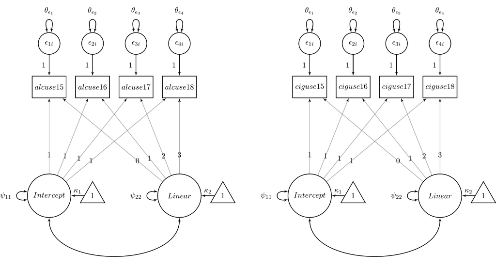

# 3.1.3 Parallel process: correlation

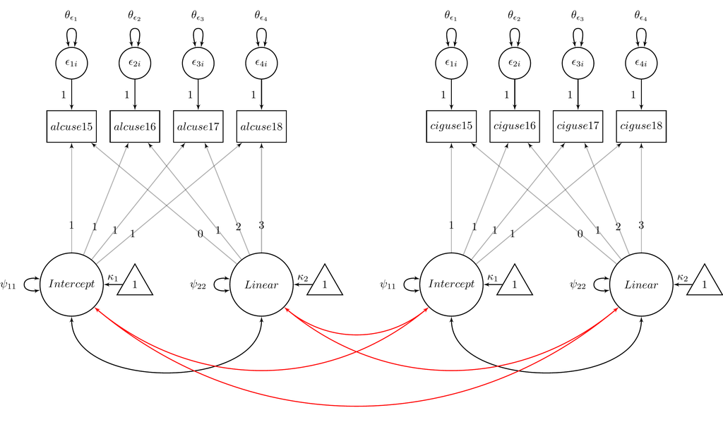

# 3.1.4 Parallel process (correlation)

“parallel process corr”

Relationship between alcohol use growth and cigarette use growth

Center alcohol use variable at age 16  
Center cigarette use at age 16

Linear growth in alcohol use  
Linear growth in cigarette use

This model also fixes residual variances for each process to be equal (within a process)

# 3.1.5 Syntax for parallel process (correlation)

`MODEL:`

`aicept alinear |`  
`alcuse10@-6 alcuse11@-5 alcuse12@-4 alcuse13@-3`  
`alcuse14@-2 alcuse15@-1 alcuse16@0 alcuse17@1`  
`alcuse18@2 alcuse19@3;`

`cicept clinear |`  
`ciguse10@-6 ciguse11@-5 ciguse12@-4 ciguse13@-3`  
`ciguse14@-2 ciguse15@-1 ciguse16@0 ciguse17@1`  
`ciguse18@2 ciguse19@3;`

`alcuse10 - alcuse19 (1);`  
`ciguse10 - ciguse19 (2);`

Note that you need **unique names** for the intercept and slope

Don’t have to explicitly ask for correlations between intercepts and slopes for each process  
- The program does that for you

# 3.2 Interpretation

# 3.2.1 Results for parallel process (correlation)

**Alcohol intercept** = 5.982, p<.001  
Average alcohol use at age 16 is 5.982  
Variance is 0.438, p<.001

**Alcohol slope** = 0.220, p<.001  
Average alcohol use increase per year is 0.220 points  
Variance is 0.022, p<.001

**Cigarette intercept** = 6.473, p<.001  
Average cigarette use at age 16 is 6.473  
Variance is 1.419, p<.001

**Cigarette slope** = 0.203, p<.001  
Average cigarette use increase per year is 0.203 points  
Variance is 0.065, p<.001

# 3.2.2 Average intercept and slope for both substances

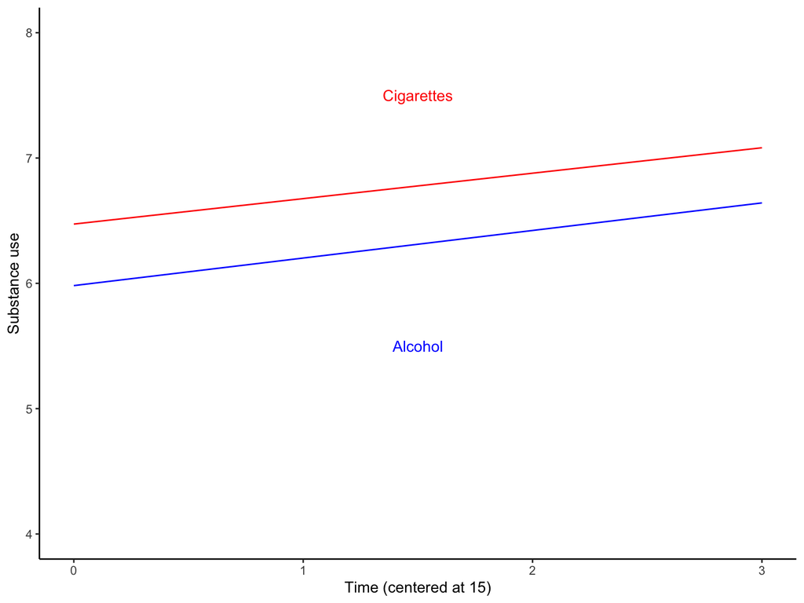

# 3.2.3 Correlations between growth parameters

Covariance **within** each growth model:

- Alcohol intercept and slope covariance = 0.032, p<.01
- Cigarette intercept and slope covariance = 0.157, p<.001

Covariance **between** growth models:

- Alcohol intercept / cigarette intercept = 0.406, p<.001
- Alcohol intercept / cigarette slope = 0.070, p<.001
- Alcohol slope / cigarette intercept = 0.014, NS
- Alcohol slope / cigarette slope = 0.030, p<.001

# 3.2.4 Conclusions 1

- On average, alcohol use increases from age 10 to 19, b = 0.220, p<.001, although there is significant variability in this increase, $\sigma^2$ = 0.022, p<.001
- On average, cigarette use increases from age 10 to 19, b = 0.203, p<.001, although there is significant variability in this increase, $\sigma^2$ = 0.065, p<.001
- Age 16 alcohol use is positively related to growth in alcohol use, $\sigma$ = 0.032, p<.01; high alcohol use at age 16 is associated with faster growth in alcohol use
- Age 16 cigarette use is positively related to growth in cigarette use, $\sigma$ = 0.157, p<.001; high cigarette use at age 16 is associated with faster growth in cigarette use

# 3.2.5 Conclusions 2

- Alcohol use at age 16 is positively related to cigarette use at age 16, $\sigma$ = 0.406, p<.001; kids using more alcohol at age 16 are also using more cigarettes at age 16, and vice versa
- Alcohol use at age 16 is positively related to growth in cigarette use, $\sigma$ = 0.070, p<.001; kids using more alcohol at age 16 have higher growth in cigarette use
- Change in alcohol use is not significantly related to cigarette use at age 16, $\sigma$ = 0.014, NS; kids using more cigarettes at age 16 DO NOT have higher growth in alcohol use
- Change in alcohol use is positively related to change in cigarette use, $\sigma$ = 0.030, p<.001; kids with high growth in alcohol use also have high growth in cigarette use

# 3.3 Parallel process: regression

# 3.3.1 Variants on parallel process models

**Center the processes at different times**

- Theory: Cigarette use at 16 is related to alcohol use at 19
- Center cigarette use at age 16, center alcohol use at age 19
- Look at the correlation between intercept and intercept

**Regressions between latent growth parameters**

- Theory: Growth in cigarette use predicts growth in alcohol use
- Include statement to predict alcohol slope from cigarette slope

**Combine both centering and prediction**

- Theory: Cigarette use at 16 predicts alcohol use at 19
- Center cigarette use at age 16, center alcohol use at age 19
- **Predict** alcohol use intercept from cigarette use intercept

# 3.3.2 Parallel process (regression)

“parallel process regress”

Cigarette use growth parameters **predict** alcohol use growth parameters

Center alcohol use variable at age 19  
Center cigarette use at age 16

Linear growth in alcohol use  
Linear growth in cigarette use

This model also fixes residual variances for each process to be equal

# 3.3.3 Syntax for parallel process (regression)

`MODEL:`

`aicept alinear |`  
`alcuse10@-9 alcuse11@-8 alcuse12@-7 alcuse13@-6`  
`alcuse14@-5 alcuse15@-4 alcuse16@-3 alcuse17@-2`  
`alcuse18@-1 alcuse19@0;`

`cicept clinear |`  
`ciguse10@-6 ciguse11@-5 ciguse12@-4 ciguse13@-3`  
`ciguse14@-2 ciguse15@-1 ciguse16@0 ciguse17@1`  
`ciguse18@2 ciguse19@3;`

`alcuse10 - alcuse19 (1);`  
`ciguse10 - ciguse19 (2);`

`aicept alinear on cicept clinear;`

# 3.4 Interpretation

# 3.4.1 Results for parallel process (regression)

Cigarette use growth model is the predictor

**Cigarette intercept** = 6.473, p<.001  
Average cigarette use at age 16 is 6.473  
Variance is 1.419, p<.001

**Cigarette slope** = 0.203, p<.001  
Average cigarette use increase per year is 0.203 points  
Variance is 0.065, p<.001

# 3.4.2 Results for parallel process (regression)

Alcohol use growth model is the outcome

**Alcohol intercept** = 5.785, p<.001  
Average alcohol use at age 19, for a person with a cigarette intercept = 0 and cigarette slope = 0, is 5.785  
**This is not really interpretable like this**  
Variance is 0.437, p<.001

**Alcohol slope** = 0.460, p<.001  
Average alcohol use increase per year, for a person with a cigarette intercept = 0 and cigarette slope = 0, is 0.460 points  
**This is not really interpretable like this**  
Variance is 0.005, NS

# 3.4.3 Relationships between growth parameters

**Covariance within each growth model**:

Alcohol intercept and slope covariance = 0.030, NS

- Note that this is now the **residual** covariance, after accounting for the prediction from cigarette use

Cigarette intercept and slope covariance = 0.157, p<.001

- This is not a residual covariance because cigarette use growth model is the predictor

**Regressions**:

- Cigarette intercept *does not* predict alcohol intercept = 0.060, NS
- Cigarette slope predicts alcohol intercept = 2.311, p<.001
- Cigarette intercept predicts alcohol slope = –0.056, p<.001
- Cigarette slope predicts alcohol slope = 0.592, p<.001

But remember that our alcohol intercept and slope are not super interpretable (yet)

# 3.4.4 Relationships between latent variables

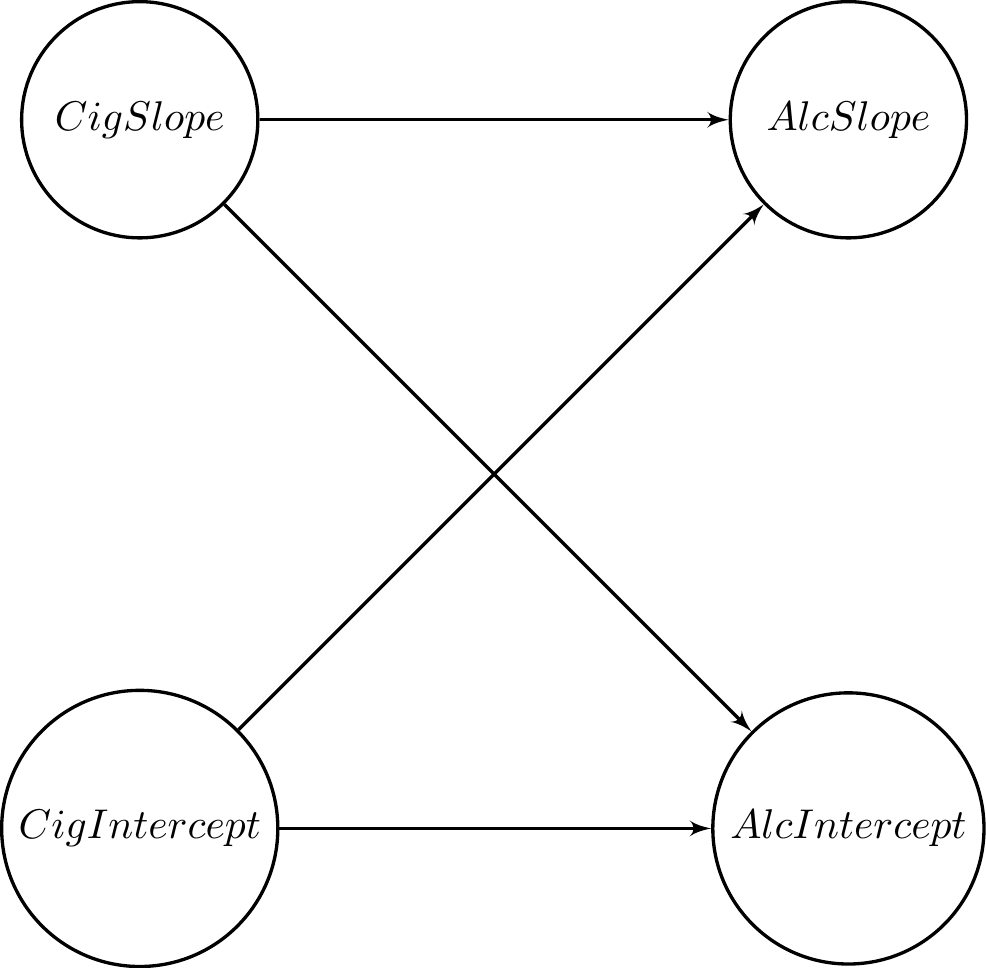

# 3.4.5 Full equations for alcohol latent variables

$$Intercept_{alcohol} = 5.785+0.060(Intercept_{cigarette}) + 2.311(Slope_{cigarette})$$
$$Slope_{alcohol} = 0.460 - 0.056(Intercept_{cigarette}) + 0.592(Slope_{cigarette})$$

The intercepts in these equations (5.785 and 0.460) are not interpretable as the *average value at age 19* and *average slope*, respectively

- They are the alcohol use value at age 19 and the average slope **if cigarette use intercept and slope are equal to 0**
- Do values of 0 for cigarette use intercept and slope even exist? And do they mean anything?
  - In this situation, no for both

# 3.4.6 Interpretable alcohol use values

How can you get interpretable values for alcohol use?

Use **average** cigarette intercept and slope in the above equations

Averge cigarette intercept = 6.473

Average cigarette slope = 0.203

$$Intercept_{alcohol} = 5.785 + 0.060 (6.473) + 2.311 (0.203) = 6.642$$
$$Slope_{alcohol} = 0.460 - 0.056 (6.473) + 0.592 (0.203) = 0.218$$

These are the average intercept and slope for alcohol use **for a person who is average on cigarette use intercept and slope**

- Typical alcohol use growth for a typical cigarette user